# Prep + brainstorming for Denny’s / La Quinta lab

## Counting

How many Denny’s per state or per square mile or thousand square miles? *LATTER LOOKS BETTER, ALSO MORE MEANINGFUL*

```r
dn %>%
  count(state) %>%
  inner_join(states, by = c("state" = "abbreviation")) %>%
  mutate(
    per_sq_mi = n / area,
    per_sq_mi_th = n / (area / 1000)
    )
```

| state | n | name | area | per_sq_mi | per_sq_mi_th |
| --- | --- | --- | --- | --- | --- |
| AK | 3 | Alaska | 665384.04 | 4.508674e-06 | 0.004508674 |
| AL | 7 | Alabama | 52420.07 | 1.335366e-04 | 0.133536640 |
| AR | 9 | Arkansas | 53178.55 | 1.692412e-04 | 0.169241170 |
| AZ | 83 | Arizona | 113990.30 | 7.281321e-04 | 0.728132131 |
| CA | 403 | California | 163694.74 | 2.461900e-03 | 2.461899509 |
| CO | 29 | Colorado | 104093.67 | 2.785952e-04 | 0.278595231 |
| CT | 12 | Connecticut | 5543.41 | 2.164733e-03 | 2.164732538 |
| DC | 2 | District of Columbia | 68.34 | 2.926544e-02 | 29.265437518 |
| DE | 1 | Delaware | 2488.72 | 4.018130e-04 | 0.401812980 |
| FL | 140 | Florida | 65757.70 | 2.129028e-03 | 2.129028235 |

[output cut: 41 more lines]

Can do the same for La Quinta as well…

## Visualizing

First need to combine the data:

```r
dn_lq <- bind_rows(dn, lq)
```

Let’s do only US for this:

```r
dn_lq_us <- dn_lq %>%
  filter(country == "United States")
```

Write out data at this stage for the shiny app:

```r
write_csv(dn_lq_us, path = "data-shiny/dn_lq_us.csv")
```

Then we plot:

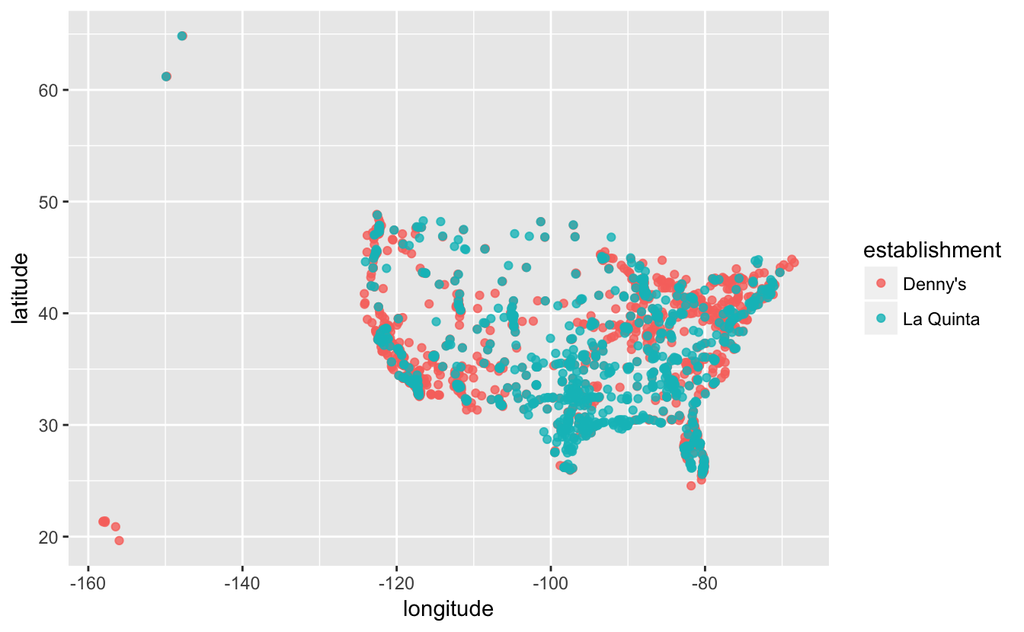

```r
ggplot(dn_lq_us, mapping = aes(x = longitude, y = latitude, color = establishment)) +
  geom_point(alpha = 0.8)
```

Should we use La Quinta and Denny’s colors? BUT THEY UGLY!!!

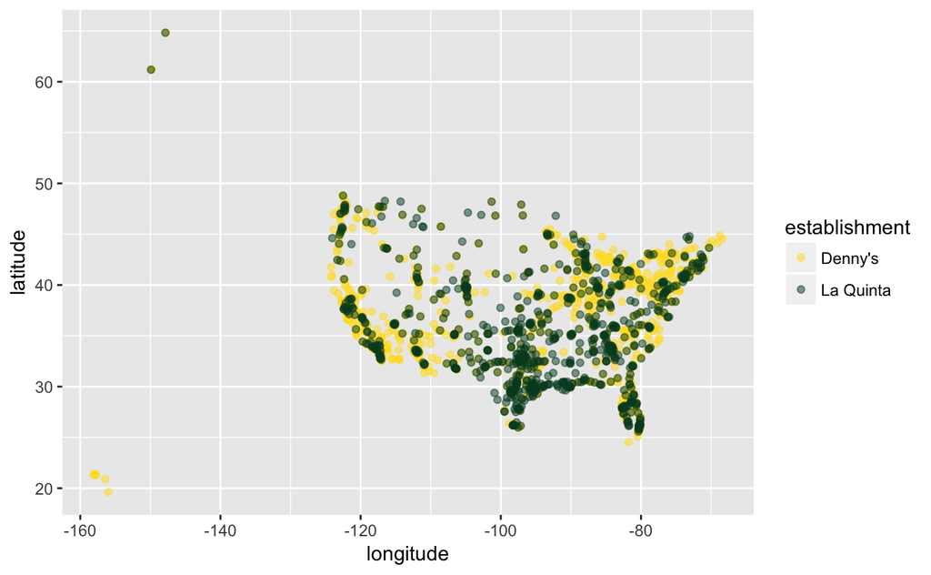

```r
lq_col <- "#004827"
dn_col <- "#FFDE23"
ggplot(dn_lq_us, mapping = aes(x = longitude, y = latitude, color = establishment)) +
  geom_point(alpha = 0.5) +
  scale_color_manual(values = c(dn_col, lq_col))
```